# Project 5 (2)

## Project 5 (KMeans Clustering)

The Wine data set consists of 13 different parameters of wine such as Alcohol, Malic, Ash, Alcalinity, Magnesium, Phenols, Flavanoids, Nonflavanoids, Proanthocyanins, Color, Hue, Dilution, and Proline content which was measured for 176 wine samples. These wines were grown in the same region in Italy but derived from different cultivars. In this project you're going to cluster the wines based on Phenols and Flavanoids.

**Question 1: Import the librarys (pandas, matplotlib, and seaborn) and read the Wine csv file into df dataframe and display first 5 rows of it**

```python
import pandas as pd
import matplotlib.pyplot as plt
import seaborn as sns
%matplotlib inline

df = pd.read_csv('Wine.csv')
df.head()
```

|  | Alcohol | Malic_Acid | Ash | Ash_Alcanity | Magnesium | Phenols | Flavanoids | Nonflavanoid_Phenols | Proanthocyanins | Color_Intensity | Hue | OD280 | Proline |
| --- | --- | --- | --- | --- | --- | --- | --- | --- | --- | --- | --- | --- | --- |
| 0 | 12.37 | 1.07 | 2.10 | 18.5 | 88 | 3.52 | 3.75 | 0.24 | 1.95 | 4.50 | 1.04 | 2.77 | 660 |
| 1 | 13.82 | 1.75 | 2.42 | 14.0 | 111 | 3.88 | 3.74 | 0.32 | 1.87 | 7.05 | 1.01 | 3.26 | 1190 |
| 2 | 14.75 | 1.73 | 2.39 | 11.4 | 91 | 3.10 | 3.69 | 0.43 | 2.81 | 5.40 | 1.25 | 2.73 | 1150 |
| 3 | 13.72 | 1.43 | 2.50 | 16.7 | 108 | 3.40 | 3.67 | 0.19 | 2.04 | 6.80 | 0.89 | 2.87 | 1285 |
| 4 | 14.38 | 1.87 | 2.38 | 12.0 | 102 | 3.30 | 3.64 | 0.29 | 2.96 | 7.50 | 1.20 | 3.00 | 1547 |

```python
import warnings
warnings.filterwarnings('ignore')
```

**Question 2: Exploratory data analysis.**

a. check the shape of dataset

```python
df.shape
```

```
(176, 13)
```

b. View the statistical summary of numerical variables (describe)

```python
df.describe().transpose()
```

|  | count | mean | std | min | 25% | 50% | 75% | max |
| --- | --- | --- | --- | --- | --- | --- | --- | --- |
| Alcohol | 176.0 | 13.002045 | 0.804145 | 11.03 | 12.3675 | 13.050 | 13.6725 | 14.83 |
| Malic_Acid | 176.0 | 2.342216 | 1.121870 | 0.74 | 1.6075 | 1.865 | 3.1050 | 5.80 |
| Ash | 176.0 | 2.360966 | 0.267880 | 1.36 | 2.2100 | 2.360 | 2.5525 | 3.22 |
| Ash_Alcanity | 176.0 | 19.460795 | 3.280905 | 10.60 | 17.2000 | 19.500 | 21.5000 | 30.00 |
| Magnesium | 176.0 | 99.585227 | 14.275398 | 70.00 | 88.0000 | 98.000 | 107.0000 | 162.00 |
| Phenols | 176.0 | 2.284375 | 0.621132 | 0.98 | 1.7350 | 2.335 | 2.8000 | 3.88 |
| Flavanoids | 176.0 | 2.001136 | 0.966694 | 0.34 | 1.1750 | 2.120 | 2.8075 | 3.75 |
| Nonflavanoid_Phenols | 176.0 | 0.361477 | 0.124855 | 0.13 | 0.2675 | 0.340 | 0.4325 | 0.66 |
| Proanthocyanins | 176.0 | 1.587784 | 0.574865 | 0.41 | 1.2475 | 1.545 | 1.9525 | 3.58 |
| Color_Intensity | 176.0 | 5.032045 | 2.313942 | 1.28 | 3.2000 | 4.640 | 6.2000 | 13.00 |
| Hue | 176.0 | 0.956057 | 0.228935 | 0.48 | 0.7800 | 0.965 | 1.1200 | 1.71 |
| OD280 | 176.0 | 2.604375 | 0.709155 | 1.27 | 1.9275 | 2.780 | 3.1700 | 4.00 |
| Proline | 176.0 | 743.193182 | 307.988380 | 278.00 | 501.5000 | 673.500 | 985.0000 | 1547.00 |

c. check for null values

```python
df.isnull().sum()
```

```
Alcohol                 0
Malic_Acid              0
Ash                     0
Ash_Alcanity            0
Magnesium               0
Phenols                 0
Flavanoids              0
Nonflavanoid_Phenols    0
Proanthocyanins         0
Color_Intensity         0
Hue                     0
OD280                   0
Proline                 0
dtype: int64
```

d. drop duplicates

```python
df.drop_duplicates(inplace=True)
```

e. Create histplot with 'kernel density estimate' for Phenols

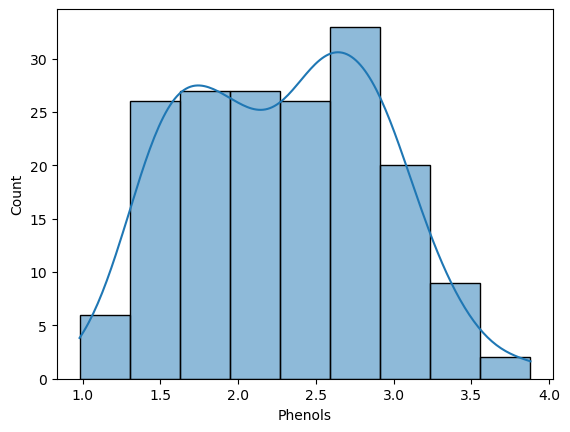

```python
sns.histplot(df['Phenols'], kde=True)
```

f. Create histplot with 'kernel density estimate' for Flavanoids

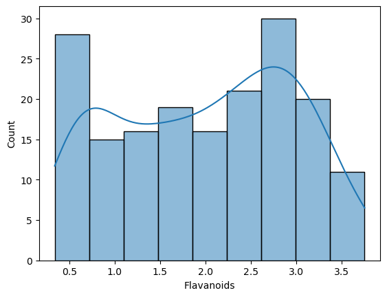

```python
sns.histplot(df['Flavanoids'], kde=True)
```

**Question 3: Import required Libraries for K-Means clustering**

```python
import sklearn
import numpy as np

from sklearn.cluster import KMeans

from sklearn.preprocessing import scale, StandardScaler
```

**Question 4: Subset the df dataframe to 'Phenols' and 'Flavanoids' and get a deep copy of df dataframe and save it in df2**

```python
df2 = df[['Phenols','Flavanoids']].copy() # subset the dataframe
```

**Question 5: Scale the data in df2 data frame and save it to scaled_data, then print the mean and std of scaled_data to make sure the data is scaled**

```python
# Cluster analysis requires us to scale the data to eliminate scaling effects in our results
scaler = StandardScaler() #this creates a scaler object
scaled_array = scaler.fit_transform(df2)# returns np array, not dataframe

df2.head()
```

|  | Phenols | Flavanoids |
| --- | --- | --- |
| 0 | 3.52 | 3.75 |
| 1 | 3.88 | 3.74 |
| 2 | 3.10 | 3.69 |
| 3 | 3.40 | 3.67 |
| 4 | 3.30 | 3.64 |

```python
# Remember [:,0] means all rows and first column!

income_average = scaled_array[:,0].mean()# income is the first column that's why we use 0 index
income_std = scaled_array[:,0].std()
giving_average=scaled_array[:,1].mean() # giving is the second column that's why we use 1 index
giving_std=scaled_array[:,1].std()

#I use the following codes only to illustrate the scales have been transformed to z-scores (mean of 0 and std of 1).

print('income mean is {:.6f}.'.format(income_average))
print('income std is {:.6f}.'.format(income_std))
print('giving mean is {:.6f}.'.format(giving_average))
print('giving std is {:.6f}.'.format(giving_std))
```

```
income mean is 0.000000.
income std is 1.000000.
giving mean is 0.000000.
giving std is 1.000000.
```

**Question 6: Identifying the number of optimal clusters**

a. Type a code to help you to get the number of optimal clusters

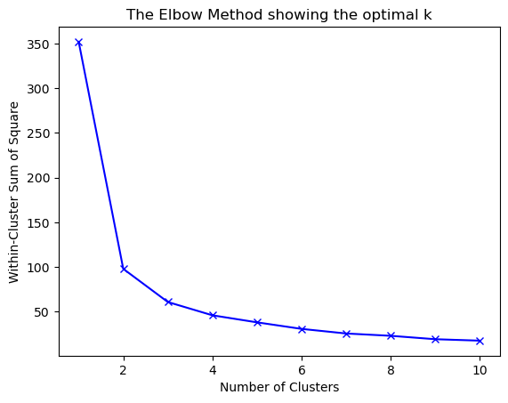

```python
wcss=[]

for i in range(1, 11):
    kmeans = KMeans(n_clusters=i, init = 'k-means++', random_state = 0)
    kmeans.fit(scaled_array)
    wcss.append(kmeans.inertia_)


plt.plot(range(1, 11), wcss, 'bx-') # bx- will add blue cross sign on the chart
plt.xlabel('Number of Clusters')
plt.ylabel('Within-Cluster Sum of Square')
plt.title('The Elbow Method showing the optimal k')
plt.show()
#plt.savefig('elbow.png')
```

b. From your elbow curve code, explain the for loop and the range() built-in function and how they work

for loop (for i in range(1, 11):): This loop iterates through values of i from 1 up to, but not including, 11, which gives the values from 1 to 10.Each value of i represents a different number of clusters (n_clusters) to try in the K-means algorithm. The loop allows us to compute the Within-Cluster Sum of Squares (WCSS) for each number of clusters (1 to 10) and see how it changes, helping us identify the optimal number of clusters.

range() function (range(1, 11)): range() generates a sequence of numbers, in this case from 1 to 10. range(1, 11) specifies a start at 1 and an end just before 11, effectively creating a sequence from 1 to 10. This function is useful for looping a specific number of times, such as trying different numbers of clusters here.

c. Explain what the within-cluster sum of squares is and identify which part of your elbow curve code calculates it. You can copy and paste the code after you have explained the within-cluster sum of squares in the following markdown cell.

The Within-Cluster Sum of Squares (WCSS) is a measure of the compactness of each cluster formed by the K-means algorithm. It calculates the sum of the squared distances between each data point in a cluster and the centroid of that cluster. thihs is the code: wcss = []

for i in range(1, 11): kmeans = KMeans(n_clusters=i, init='k-means++', random_state=0) kmeans.fit(scaled_array) wcss.append(kmeans.inertia_)

d. From your elbow curve code, copy and paste the part of the code that is used for initializing the centroids of the clusters.

kmeans = KMeans(n_clusters=i, init='k-means++', random_state=0)

e. Based on your elbow curve output, what is the optimal number of clusters?

3

f. Explain the reason for choosing certain number of clusters as optimal number of clusters:

In the elbow method, we look for the "elbow" point in the curve, where the Within-Cluster Sum of Squares (WCSS) decreases sharply and then starts to level off. The WCSS drops steeply between 1 and 3 clusters, indicating that adding clusters in this range significantly improves the compactness of the clusters. After 3 clusters, the reduction in WCSS becomes smaller and less significant. This indicates that adding more clusters does not provide substantial improvement in clustering quality

**Question 6:**

a. Explain K-means clustering in your own words? What does it do and how does it work?

K-means clustering helps identify natural groupings in data, allowing us to segment data into meaningful clusters. This is useful in many fields, like customer segmentation in marketing, image compression, and anomaly detection, where grouping similar data points is valuable.

b. Do K-means clustering

```python
kmeans = KMeans(n_clusters = 3, init = 'k-means++', random_state = 0) # <-- use random_state = 0  to get my result
kmeans = kmeans.fit(scaled_array)
```

c. Explain the above code in your own words?

KMeans(n_clusters=3):n_clusters=3 specifies that the data should be grouped into 3 clusters. This means the algorithm will try to find 3 distinct groups in the data.

init='k-means++':The init='k-means++' parameter specifies the initialization method for the centroids. The "k-means++" method chooses initial cluster centers in a way that speeds up convergence and improves the quality of the final clusters, as compared to randomly picking initial points.

random_state=0:random_state=0 is a seed value for the random number generator. Setting this ensures reproducibility of the results. Each time the code is run with random_state=0, it will produce the same initial centroid positions, resulting in the same clusters. Without a fixed random state, the clusters might differ each time.

kmeans.fit(scaled_array): fit(scaled_array) applies the K-means clustering algorithm to the dataset scaled_array. scaled_array is the input data, assumed to be scaled (normalized or standardized), which helps improve clustering performance by ensuring that each feature has a similar range. After this step, the kmeans object will contain information about the clusters, such as cluster centers (kmeans.cluster_centers_) and labels for each data point (kmeans.labels_).

d. Identify the coordinates of the unscaled centroids.

```python
unscaled_centroids = scaler.inverse_transform(kmeans.cluster_centers_)
unscaled_centroids
```

```
array([[2.25392857, 2.05696429],
       [2.95737705, 3.0357377 ],
       [1.61745763, 0.87847458]])
```

e. Store the unscaled centroids in a new dataframe called **centroids_df** with centroid_Phenols and centroid_Flavanoids as column names (Display centroids dataframe in the output)

```python
centroids_df = pd.DataFrame({'centroid_Phenols':unscaled_centroids[:,0],'centroid_Flavanoids':unscaled_centroids[:,1]})
centroids_df
```

|  | centroid_Phenols | centroid_Flavanoids |
| --- | --- | --- |
| 0 | 2.253929 | 2.056964 |
| 1 | 2.957377 | 3.035738 |
| 2 | 1.617458 | 0.878475 |

f. Explain what centroids are. In total, how many centroids do your clusters have?

centroid is the center point of a cluster. It represents the "average" position of all data points within that cluster. For each cluster, the centroid is calculated as the mean of the feature values of all points in the cluster. There are 3 centroids in total, one for each cluster.

**Question 7: Store the cluster numbers under cluster_label column in the df2 dataframe** (display first 5 rows of df2 dataframe to make sure cluster_label column is added)

```python
df2['cluster_label'] = kmeans.labels_.astype(int)
df2.head(5)
```

|  | Phenols | Flavanoids | cluster_label |
| --- | --- | --- | --- |
| 0 | 3.52 | 3.75 | 1 |
| 1 | 3.88 | 3.74 | 1 |
| 2 | 3.10 | 3.69 | 1 |
| 3 | 3.40 | 3.67 | 1 |
| 4 | 3.30 | 3.64 | 1 |

**Question 8: Plot the KMeans clustering results using a scatterplot.**

- Change the color of the dots based on 'cluster_label'.
- Create your own palette and name it palette1. Assign different colors to each cluster, using colors of your choice (except orange).
- Ensure the centroids are colored in 'orange'.
- Add the x-axis label: 'Phenols'.
- Add the y-axis label: 'Flavanoids'.
- Add the title: 'Clustering with Phenols and Flavanoids'.

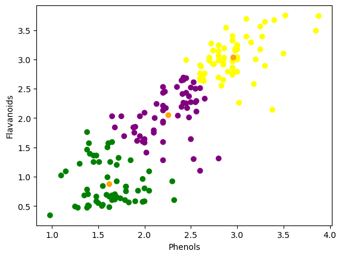

```python
# plot the results using the cluster number as the color
# centroids appear in red

LABEL_COLOR_MAP = {0 : 'purple',1 : 'yellow',2:'green', 3:'blue'}
plt.scatter(df2['Phenols'], df2['Flavanoids'], c=df2['cluster_label'].map(LABEL_COLOR_MAP)) # (x,y,color)
plt.scatter(centroids_df['centroid_Phenols'], centroids_df['centroid_Flavanoids'], c='orange') # (x,y,color)
plt.xlabel('Phenols')
plt.ylabel('Flavanoids')
#plt.savefig('kmeans image')
plt.show()
```

**Question 9: Interpret the results in detail. What does each cluster tell us?**

Green Cluster (Lower Phenols, Lower Flavanoids): This cluster appears in the lower-left region, where both phenols and flavanoids are low. Purple Cluster (Moderate Phenols, Moderate Flavanoids): The purple cluster is centrally located with moderate levels of phenols and flavanoids. Yellow Cluster (Higher Phenols, Higher Flavanoids): The yellow cluster is located towards the top-right, with high levels of both phenols and flavanoids.